# Data621_HW2Sanjive

sanjivek

June 22, 2016

```r
library(knitr)
library(dplyr)
library(tidyr)
library(pROC)
library(zoo)
raw=read.csv("https://raw.githubusercontent.com/ksanju0/DATA-621/master/classification-output-data.csv", sep = ",", header= TRUE)

t <- table(raw[ , c(10,9)])
rownames(t) <- c('Real Positive', 'Real Negative')
colnames(t) <- c('Model Positive', 'Model Negative')

getConfusionMatrix <- function(df) {
  t <- table(df$class,df$scored.class)
  rownames(t) <- c('Real Positive', 'Real Negative')
  colnames(t) <- c('Model Positive', 'Model Negative')

  return(t)
}

getAccuracy <- function(df) {
  cm <- getConfusionMatrix(df)

  tn <- cm["Real Negative", "Model Negative"]
  fp <- cm["Real Negative", "Model Positive"]
  fn <- cm["Real Positive", "Model Negative"]
  tp <- cm["Real Positive", "Model Positive"]

  accuracy <- (tn+tp) / (tn+fp+fn+tp)
  return(accuracy)
}

getCER <- function(df) {
  cm <- getConfusionMatrix(df)

  tn <- cm["Real Negative", "Model Negative"]
  fp <- cm["Real Negative", "Model Positive"]
  fn <- cm["Real Positive", "Model Negative"]
  tp <- cm["Real Positive", "Model Positive"]

  cer <- (fp + fn) / (tn+fp+fn+tp)
  return(cer)
}

getPrecision <- function(df) {
  cm <- getConfusionMatrix(df)


  tn <- cm["Real Negative", "Model Negative"]
  fp <- cm["Real Negative", "Model Positive"]
  fn <- cm["Real Positive", "Model Negative"]
  tp <- cm["Real Positive", "Model Positive"]

  precision <- tp / (fp+tp)
  return(precision)

}

getSensitivity <- function(df){
  cm <- getConfusionMatrix(df)


  tn <- cm["Real Negative", "Model Negative"]
  fp <- cm["Real Negative", "Model Positive"]
  fn <- cm["Real Positive", "Model Negative"]
  tp <- cm["Real Positive", "Model Positive"]

  sensitivity <- tp/(tp+fn)

  return(sensitivity)
}

getSpecificity <- function(df){
  cm <- getConfusionMatrix(df)


  tn <- cm["Real Negative", "Model Negative"]
  fp <- cm["Real Negative", "Model Positive"]
  fn <- cm["Real Positive", "Model Negative"]
  tp <- cm["Real Positive", "Model Positive"]

  specificity <- tn / (tn+fp)
  return(specificity)
}

getF1Score <- function(df) {

  cm <- getConfusionMatrix(df)


  tn <- cm["Real Negative", "Model Negative"]
  fp <- cm["Real Negative", "Model Positive"]
  fn <- cm["Real Positive", "Model Negative"]
  tp <- cm["Real Positive", "Model Positive"]

  precision <- getPrecision(df)
  sensitivity <- getSensitivity(df)
  f1score <- 2* (precision * sensitivity) / (precision+sensitivity)

  return(f1score)

}
```

### Question 9:

#### Before we move on, let’s consider a question that was asked: What are the bounds on the F1 score? Show that the F1 score will always be between 0 and 1. (Hint: If 0 < 𝑎 < 1 and 0 < 𝑏 < 1 then 𝑎𝑏 < 𝑎.)

### Answer:

#### Yes, The F1 score is bound by 0 and 1. Reason is both Precision (P) and the Sensitivity(S) are bound by 0 and 1 because they represents $\frac{a}{a+b}$, where a and b >0 or positive (and one of them can be 0.)

#### Hence F1 score, with Precision and Sensitivity, formula we have:

$F1\ Score = \frac{P*S + P*S}{P + S}$

#### Since both P and S are bound by 0 and 1, hence, ps < p and ps < s

#### Which means, PS + PS < P + S, i.e. F1 score is bound by 0 and 1.

### Question 10:

#### Write a function that generates an ROC curve from a data set with a true classification column (class in our example) and a probability column (scored.probability in our example). Your function should return a list that includes the plot of the ROC curve and a vector that contains the calculated area under the curve (AUC). Note that I recommend using a sequence of thresholds ranging from 0 to 1 at 0.01 intervals.

#### Area calculated is:

```r
library(zoo)
ROCf <- function(raw) {

refData <- raw[,c(9,10,11)]
thresh <- seq(0.01, 1, by = .01)
Speci <- rep(0.0, 100)
Sensi <- rep(0.0, 100)

for(k in 1:100) {
    thresh.pred <- rep(0, nrow(refData))
    thresh.pred[refData$scored.probability > thresh[k] ] <- 1
    Speci[k] <- 1 - calcSpecificity(refData$class, as.matrix(thresh.pred))
    Sensi[k] <- calcSensitivity(refData$class, as.matrix(thresh.pred))

    if (thresh[k] == 0.5) {
      SpeciNew <- Speci[k]
      SensiNew <- Sensi[k]
    }

  }

  plot(Speci, Sensi, xlab = "1 - Specificity", ylab = "Sensitivity", main = "ROC Chart", col = "blue")

  #Area calculated is:
  AUC <- -1*sum(diff(na.omit(Speci))*rollmean(na.omit(Sensi),2))
  AUC

}

calcSensitivity <- function(actual, predicted) {

        c.mat <- data.frame(table(actual, predicted))
        TN <- as.numeric(as.character(c.mat[1,3]))
        FN <- as.numeric(as.character(c.mat[2,3]))
        FP <- as.numeric(as.character(c.mat[3,3]))
        TP <- as.numeric(as.character(c.mat[4,3]))

        return( TP / (TP + FN) )
    }

calcSpecificity <- function(actual, predicted) {
      c.mat <- data.frame(table(actual, predicted))
      TN <- as.numeric(as.character(c.mat[1,3]))
      FN <- as.numeric(as.character(c.mat[2,3]))
      FP <- as.numeric(as.character(c.mat[3,3]))
      TP <- as.numeric(as.character(c.mat[4,3]))
    return( TN / (TN + FP) )
    }
```

#### You can plot the ROC Curev using the below script and passing the dataset:

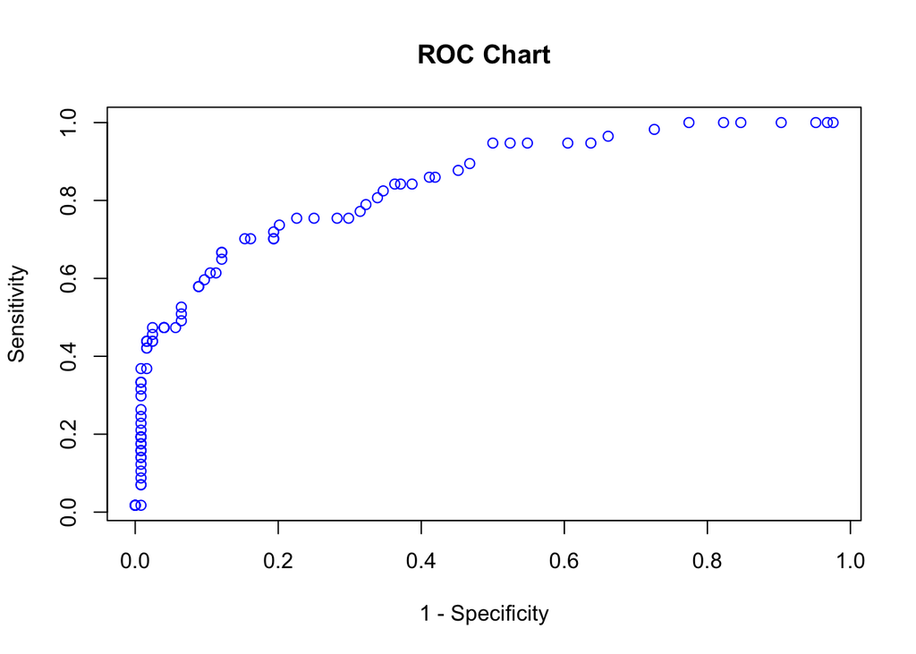

```
## [1] 0.8247029
```

```r
ROCf(raw)
```

### Question 11:

#### Use your created R functions and the provided classification output data set to produce all of the classification metrics discussed above.

#### Here is the results of all the functions we have created above:

```r
getAccuracy(raw)
```

```
## [1] 0.8066298
```

```r
getCER(raw)
```

```
## [1] 0.1933702
```

```r
getPrecision(raw)
```

```
## [1] 0.7986577
```

```r
getSensitivity(raw)
```

```
## [1] 0.9596774
```

```r
getSpecificity(raw)
```

```
## [1] 0.4736842
```

```r
getF1Score(raw)
```

```
## [1] 0.8717949
```

[output not shown]

[output not shown]

### Question 12:

#### Investigate the caret package. In particular, consider the functions confusionMatrix, sensitivity, and specificity. Apply the functions to the data set. How do the results compare with your own functions?

```r
library(caret)
confusionMatrix(factor(raw$scored.class),factor(raw$class),positive="0")
```

```
## Confusion Matrix and Statistics
##
##           Reference
## Prediction   0   1
##          0 119  30
##          1   5  27
##
##                Accuracy : 0.8066
##                  95% CI : (0.7415, 0.8615)
##     No Information Rate : 0.6851
##     P-Value [Acc > NIR] : 0.0001712
##
##                   Kappa : 0.4916
##  Mcnemar's Test P-Value : 4.976e-05
##
##             Sensitivity : 0.9597
##             Specificity : 0.4737
##          Pos Pred Value : 0.7987
##          Neg Pred Value : 0.8438
##              Prevalence : 0.6851
##          Detection Rate : 0.6575
##    Detection Prevalence : 0.8232
##       Balanced Accuracy : 0.7167
##
##        'Positive' Class : 0
##
```

```r
sensitivity(factor(raw$scored.class),factor(raw$class),positive="0")
```

```
## [1] 0.9596774
```

```r
specificity(factor(raw$scored.class),factor(raw$class), positive = "0")
```

```
## [1] 0.4736842
```

Comparing with our function as :

[output not shown]

### Question 13.

#### Investigate the pROC package. Use it to generate an ROC curve for the data set. How do the results compare with your own functions?

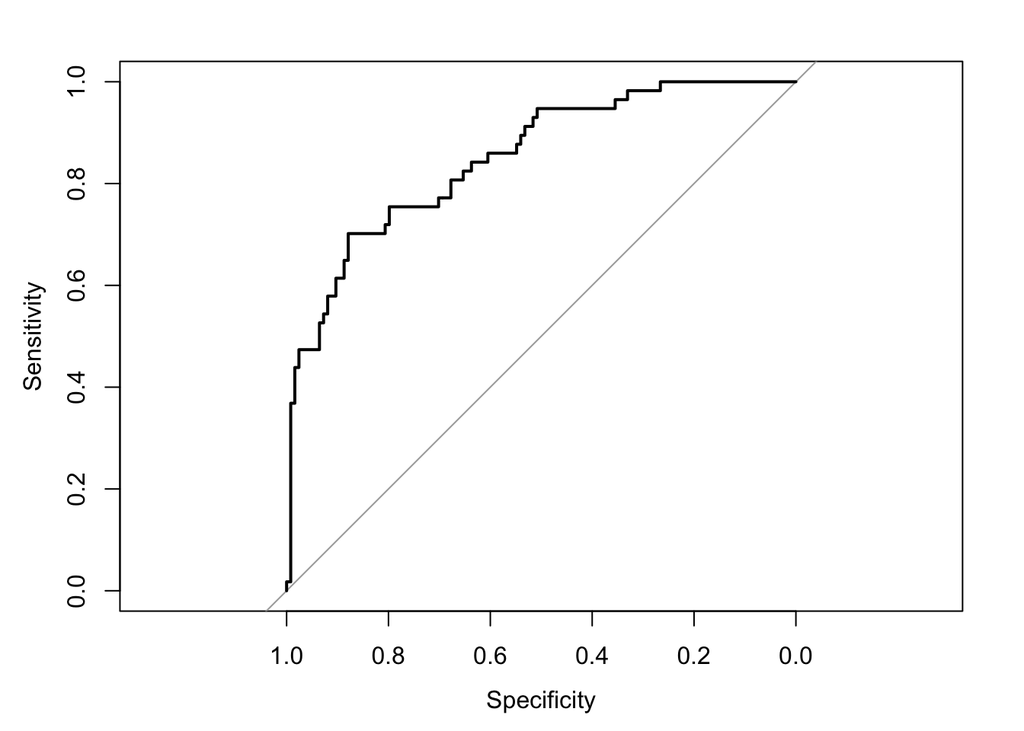

```
##
## Call:
## roc.formula(formula = factor(class) ~ scored.probability, data = raw)
##
## Data: scored.probability in 124 controls (factor(class) 0) < 57 cases (factor(class) 1).
## Area under the curve: 0.8503
```

```r
library(pROC)

rocP <- roc(factor(class) ~ scored.probability, data=raw)

plot(rocP)
```

#### Comparing the custom function with the pROC Package as:

| Approach | AUC |
| --- | --- |
| Custom Fuction | 0.8247 |
| pROC Package | 0.8503 |